# Textual Taylor Rule

Nicole Rae Baerg and Will Lowe

28/05/20187

## R Setup

```r
library(lme4)
library(splines)
library(ggplot2)
library(dplyr)
library(readr)
library(stargazer)
library(readxl)
library(lubridate)
library(broom)
library(tidyr)
library(cowplot)
library(xtable)
library(quanteda) #tested on 1.2 or 1.3, 0.9 is not the same output
```

Please note that quanteda 1.3 was used and is necessary to replicate the results in A.1 in the Appendix Material. For your conevience, a copy of the package is contained in this replication repositroy

## This is Figure 1

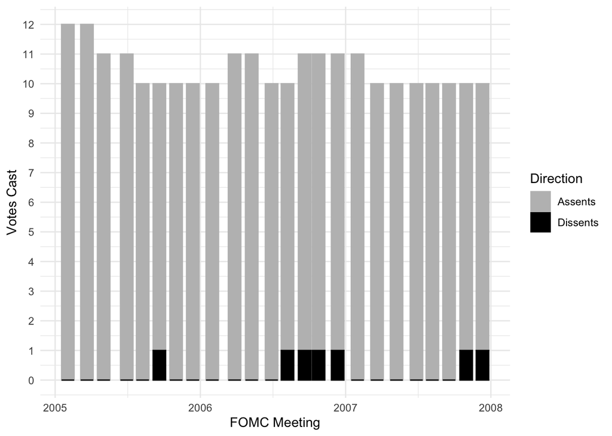

```r
read_excel("FOMC_Dissents_Data.xlsx", skip = 3, col_names = TRUE) %>%
  filter(Year >= 2005, Year <= 2007) %>%
  group_by(`FOMC Meeting`) %>%
  mutate(diss = `Number Presidents Dissenting` + `Number Governors Dissenting`) %>%
  summarise(total = `FOMC Votes`, Assents = total - diss, Dissents = diss) %>%
  gather(Direction, Votes, -c(`FOMC Meeting`, total)) %>%
  ggplot(aes(x = `FOMC Meeting`, y = Votes, colour = Direction, fill = Direction)) +
  geom_bar(stat = "identity") +
  scale_colour_manual(values = c("grey", "black")) +
  scale_fill_manual(values = c("grey", "black")) +
  scale_y_continuous("Votes Cast", breaks = 0:12, labels = as.character(0:12)) +
  theme_minimal()
```

```r
# ggsave("dissentsplot.pdf", width = 7, height = 5)
```

## FOMC members preferences

This section pulls in the data and makes the dependent variable for modeling. The first function is the ideal point plotter (dotchart + segments but in ggplot)

```r
ipplot <- function(ideal, speaker, lower, upper){
  row <- 1:length(ideal)
  p <- ggplot(df, aes(ideal, speaker)) +
    geom_point(size = 2) +
    geom_segment(aes(x=lower, xend=upper, y=row, yend=row)) +
    theme_minimal() +
    theme(panel.grid.major.x = element_blank(),
          panel.grid.minor = element_blank())
  p
}
```

This lists the names of FOMC members per year that we care about.

```r
nicole_peeps2007 <- c("GREENSPAN", "GEITHNER", "BIES", "EVANS",
                      "FISHER", "FERGUSON", "GUYNN", "KOHN",
                      "LOCKHART", "LACKER", "PIANALTO", "YELLEN",
                      "MINEHAN", "MOSKOW", "POOLE", "HOENIG",
                      "FISHER", "STERN", "SANTOMERO")
nicole_peeps2006 <- c("BERNANKE", "GEITHNER", "BIES", "HOENIG",
                      "KOHN", "KROSZNER", "MINEHAN", "MISHKIN",
                      "MOSKOW", "POOLE", "WARSH", "FISHER", "OLSON",
                      "PIANALTO", "PLOSSER", "STERN", "STONE",
                      "LACKER", "YELLEN")
nicole_peeps2005 <- c("GREENSPAN", "GEITHNER", "BERNANKE", "BIES",
                      "FERGUSON", "FISHER", "GRAMLICH", "KOHN",
                      "MOSKOW", "OLSON", "SANTOMERO", "STERN",
                      "GUYNN", "LACKER", "PIANALTO", "YELLEN",
                      "HOENIG", "MINEHAN", "POOLE", "HOLCOMB",
                      "CUMMING")
nicole_peeps <- unique(c(nicole_peeps2007, nicole_peeps2006,
                         nicole_peeps2005))
```

This is the meeting data and the topic output

```r
# meeting data and speaker metadata
ddm <- read.csv("name_role_date.csv")
# topic model output
c_file <- 'topical-ngrams-document-topics.csv'
dd1 <- read.csv(c_file, sep = '\t')[,-1]
names(dd1) <- 0:24 # these are the topics, from 1 to 25
```

Now to pick out the topics we are interested in (we do this by hand i.e. determine which topics):

- 7+17+21 (employment / output)
- 8 (core inflation) (9, 14, 15: energy + house prices)

Let’s have them as constants:

```r
# full sample left and right categories
R_cats_full <- '8'
L_cats_full <- c('7', '17', '21')

## and a function to create an appropriate DV with such things
mk_dv <- function(mat, right, left, na.omit = FALSE){
  res <- data.frame(R = rowSums(mat[, right, drop = FALSE]),
                    L = rowSums(mat[, left, drop = FALSE]))
  if (na.omit)
    return(na.omit(res))
  res
}

# switch dd to the numerical column labels
# names(dd) <- c('7', '17', '21', '8')
dd <- dd1[,c('7','17','21','8','9','14','15')]
```

```r
good <- rowSums(dd) > 0
meta <- filter(ddm, good, name %in% nicole_peeps)
counts <- filter(dd, good, ddm$name %in% nicole_peeps)
```

## Let’s get to modeling

In these regressions the dependent variable is two counts for each speaker-meeting

> [successes (right, inflation talk), failures (left, unemployment-output talk)]

```r
# collapse over three topic counts (see Lowe et al. 2011) and regress
depvar <- mk_dv(counts, R_cats_full, L_cats_full)
meta <- meta %>%
  mutate(month = month(date, label = TRUE),
         year = year(date))
```

## Linear mixed effects

Models for both the Bank Presidents and also the Board Members

```r
mod.mix <- glmer(as.matrix(depvar) ~ (1 | name) + (1 | month),
                 data = meta, family = binomial)
```

```r
rf <- ranef(mod.mix, condVar = TRUE)$name
rf_postvar <- as.vector(attr(rf, "postVar"))
df <- data.frame(ideal = rf[[1]]) %>%
  mutate(se = sqrt(rf_postvar),
         upper = ideal + 2 * se,
         lower = ideal - 2 * se,
         speaker = factor(rownames(rf),
                          levels = rownames(rf)[order(ideal)])) %>%
  arrange(ideal)
```

## This is Figure 2

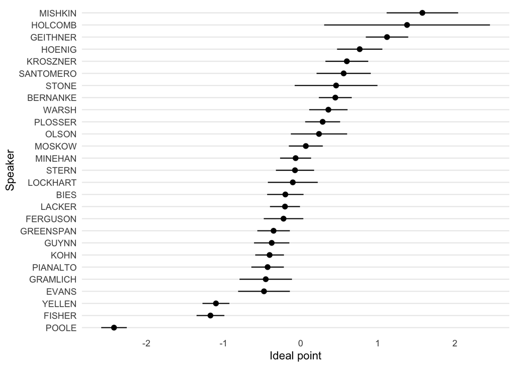

```r
ipplot(df$ideal, df$speaker, df$lower, df$upper) +
     labs(x = "Ideal point", y = "Speaker")
```

## Doing things with the estimates

## 1. Compare with other measures

```r
merged_votes_text <- read.csv("merged_votes_text.csv",
                              row.names = 1, stringsAsFactors = FALSE)
```

Expert Order of the FT Ranking is:

```r
ft_coding <- data.frame(Name = c("Kohn", "Yellen", "Bernanke", "Pianalto",
                                "Fisher", "Lacker", "Plosser", "Hoenig"),
                                 coding = c("Super Dove", "Dove", "Center", "Center",
                                "Hawk", "Super Hawk", "Super Hawk", "Super Hawk"),
             stringsAsFactors = FALSE)
```

These are the votes by Eijffinger, Sylvester CW, Ronald Mahieu, and Louis Raes. “Hawks and Doves at the FOMC.” (2015), kindly provided by the authors.

```r
votes.implied <- merged_votes_text[,6:9]
names(votes.implied) <- c("Names", "Low.Votes", "Estimate", "High.Votes")
```

This is the regional information:

The regional estimates are from here Bennani, Hamza, Etienne Farvaque, and Piotr Leszek Stanek. “FOMC members’ incentives to disagree: regional motives and background influences.” (2015).

```r
votes.regional <- read.csv("policy_rate_validation.csv",
                           stringsAsFactors = FALSE, row.names = 1) %>%
  mutate(NAME = toupper(name))
```

```r
est <- read.csv("idealcompare.csv",
                stringsAsFactors = FALSE, row.names = 1)

df <- merged_votes_text %>%
  left_join(votes.regional, by = "NAME") %>%
  left_join(est, by = "NAME") %>%
  mutate(Pref.low = Pref.Policy - 1.96 * Pref.STD,
         Pref.high = Pref.Policy + 1.96 * Pref.STD,
         med.votes.sd = (med.votes - high.votes) / 1.96) %>%
  arrange(ideal) %>%
  mutate(ordered = 1:n())


small_df <- df %>%
  right_join(ft_coding, by = "Name") %>%
  select(NAME, ideal, upper, lower, coding) %>%
  mutate(coding = factor(coding,
                         levels = c("Super Dove", "Dove", "Center", "Hawk", "Super Hawk"))) %>%
  arrange(coding, ideal) %>%
  mutate(row = 1:n())
```

FT rankings and ideal points plot

## This is Figure 3

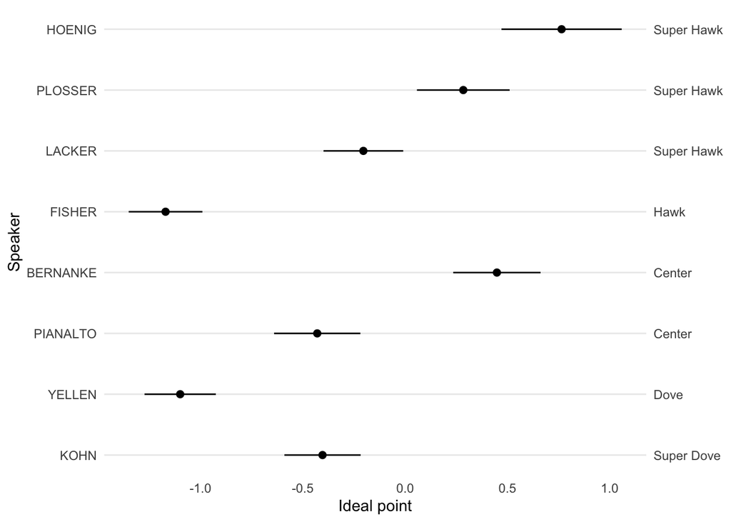

```r
labs1 <- small_df$NAME
labs2 <- small_df$coding

ggplot(small_df, aes(x = ideal, y = row)) +
  geom_point(size = 2) +
  geom_segment(aes(x = lower, xend = upper, y = row, yend = row)) +
  scale_y_continuous(breaks = 1:length(labs1),
                     labels = labs1,
                     sec.axis = sec_axis(~.,
                                         breaks = 1:length(labs2),
                                         labels = labs2)) +
  theme_minimal() +
  theme(panel.grid.major.x = element_blank(),
        panel.grid.minor = element_blank(),
        legend.title = element_blank(),
        legend.background = element_blank()) +
   labs(x = "Ideal point", y = "Speaker")
```

```r
# ggsave("rank.pdf", width = 7, height = 5)
```

# Graph

```r
nms <- df$NAME
g_text <- ggplot(df, aes(x=ideal, y=ordered)) +
  geom_point() +
  geom_errorbarh(aes(xmin = lower, xmax = upper, height = 0)) +
  theme_bw() +
  scale_y_continuous(breaks = 1:length(nms),
                     labels = nms) +
  theme(axis.title = element_blank(),
        panel.grid.major.x = element_blank(),
        panel.grid.minor = element_blank(),
        plot.title = element_blank()) +
        #axis.text.y = element_text(face = c(rep("plain",15),rep("bold",8)))) +
  ggtitle("Text Measure")

g_votes <- ggplot(df, aes(x=med.votes, y=ordered)) +
  geom_point() + geom_errorbarh(aes(xmin = low.votes, xmax = high.votes, height = 0)) +
  theme_bw() +
  theme(axis.text.y = element_blank(), axis.title = element_blank(),
        panel.grid.major.x = element_blank(),
        panel.grid.minor = element_blank(),
        plot.title = element_blank()) +
  ggtitle("Vote Measure") +
  xlim(-4,4)

g_region <- ggplot(df, aes(x=Pref.Policy, y=ordered)) +
  geom_point() + geom_errorbarh(aes(xmin = Pref.Policy - 1.96*Pref.STD,
                                    xmax = Pref.Policy + 1.96*Pref.STD, height = 0 )) +
  theme_bw() +
  theme(axis.text.y = element_blank(), axis.title = element_blank(),
        panel.grid.major.x = element_blank(),
        panel.grid.minor = element_blank(),
        plot.title = element_blank()) +

  ggtitle("Regional Vote Measure") +
  xlim(-10,10)
```

## This is Figure 4

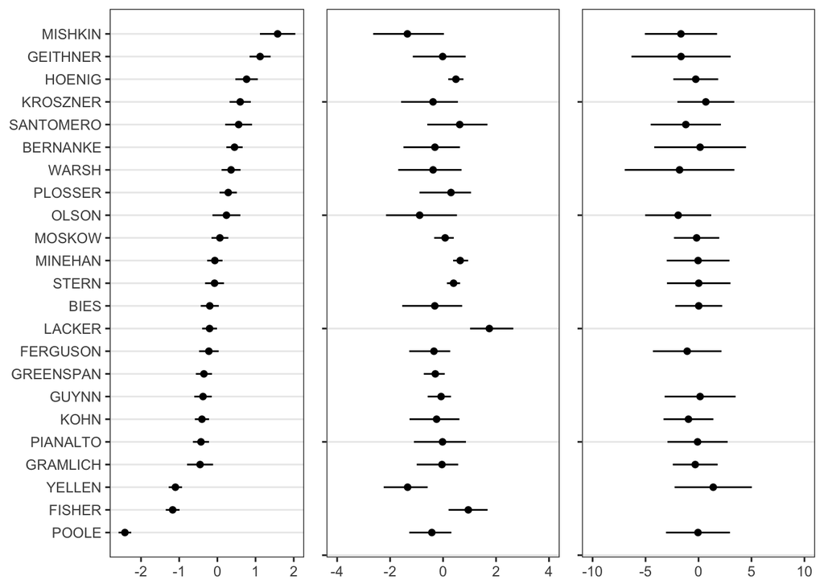

## Part 2. Adding in the economic covariates

```r
regional <- read_excel("GreenbookForecastsRegional.xlsx") %>%
  mutate(reg_un = `Regional Unemployment in Month of Meeting`,
         nat_un = `Projected Unemployment Current`,
         nat_un_q4 = `Projected Unemployment 4-Q AH`,
         nat_inf = `Projected Inflation Current Q CPI`,
         nat_inf2 =  `Projected Inflation Current Q PCE`,
         nat_inf_q42 = `Projected Inflation 4-Q AH PCE`,
         nat_inf_q4 = `Projected Inflation 4-Q AH CPI`,
         diff = nat_un - reg_un,
         logit = log(nat_un / reg_un),
         npl = as.numeric(amount), #non-performing loans
         date = as.Date(Meeting)) %>%
  filter(District != 0)
```

1. Model with national inflation + regional (district) unemployment + differennce between national and regional

```r
dat <- bind_cols(meta, depvar) %>%
  mutate(date = dmy(date)) %>%
  left_join(regional, ., by = c('name', 'date'))
mod.econ <- glmer(cbind(R, L) ~ (1 | name) + nat_inf + nat_un + diff , data = dat, family = binomial)
summary(mod.econ)
```

```r
mod.econ2 <- glmer(cbind(R, L) ~ (1 | name) + log(npl) + nat_un + diff, data = dat, family = binomial)
summary(mod.econ2)
```

```r
mod.econ3 <- glmer(cbind(R, L) ~ (1 | name) + nat_inf_q4 + nat_un_q4 + diff,  data = dat, family = binomial)
summary(mod.econ3)
```

The source of the CPI data is the Bureau of Labor Statistics http://www.usinflationcalculator.com/inflation/historical-inflation-rates/

```r
bls_cpi_inflation <- c(2.1,2.4, 2.8,    2.6,    2.7,    2.7,    2.4,    2.0,    2.8,    3.5,    4.3,    4.1, #2005
          4.0,  3.6,    3.4,    3.5,    4.2,    4.3,    4.1,    3.8,    2.1,    1.3,    2.0,    2.5,    #2006
          3.0,  3.0,    3.1,    3.5,    2.8,    2.5,    3.2,    3.6,    4.7,    4.3,    3.5,    3.4)    #2007
```

Okay, now putting these things into a table, we get the following:

## This is Table 1

```r
stargazer(mod.econ, mod.econ2, mod.econ3, type="text",
          title="Regression Results for FOMC Bank Presidents", single.row=TRUE,
          ci=TRUE, ci.level=0.9, omit.stat=c("f", "ser"))
```

```
Regression Results for FOMC Bank Presidents
====================================================================================================
                                                  Dependent variable:
                    --------------------------------------------------------------------------------
                                                      cbind(R, L)
                               (1)                        (2)                        (3)
----------------------------------------------------------------------------------------------------
nat_inf               0.007 (-0.010, 0.024)
log(npl)                                        0.415*** (0.314, 0.517)
nat_un              -0.466*** (-0.585, -0.347) -0.318*** (-0.440, -0.195)
nat_inf_q4                                                                -0.456*** (-0.567, -0.344)
nat_un_q4                                                                 -0.741*** (-0.992, -0.489)
diff                -0.253*** (-0.366, -0.141) -0.245*** (-0.358, -0.133) -0.371*** (-0.489, -0.252)
Constant             6.035*** (5.338, 6.732)     -0.866 (-2.680, 0.947)    8.453*** (7.041, 9.865)
----------------------------------------------------------------------------------------------------
Observations                   175                        175                        175
Log Likelihood              -1,098.516                 -1,074.790                 -1,092.171
Akaike Inf. Crit.           2,207.032                  2,159.580                  2,194.342
Bayesian Inf. Crit.         2,222.856                  2,175.404                  2,210.166
====================================================================================================
Note:                                                                    *p<0.1; **p<0.05; ***p<0.01
```

## Part 3. Voting Analysis

```r
dat <- read_excel("ideal_date.xlsx") %>%
  mutate(dissent = ifelse(Consent.Policy.Vote == 0, 1, 0),
         vote = if_else(Vote == "y", 1, 0),
         statement = if_else(Consent.Policy.Statement == 0, 1, 0))

mod.1 <- glmer(dissent ~  est  + vote + (1 | date), data = dat, family = binomial)
mod.2 <- glmer(statement ~ est +  vote +  (1 | date), data = dat, family = binomial)

summary(mod.1)
```

```
Generalized linear mixed model fit by maximum likelihood (Laplace
  Approximation) [glmerMod]
 Family: binomial  ( logit )
Formula: dissent ~ est + vote + (1 | date)
   Data: dat

     AIC      BIC   logLik deviance df.resid
   209.2    225.3   -100.6    201.2      401

Scaled residuals:
    Min      1Q  Median      3Q     Max
-0.7197 -0.2702 -0.2060 -0.1433  5.2235

Random effects:
 Groups Name        Variance Std.Dev.
 date   (Intercept) 1.14     1.068
Number of obs: 405, groups:  date, 24

Fixed effects:
            Estimate Std. Error z value Pr(>|z|)
(Intercept) -2.61019    0.42418  -6.154 7.58e-10 ***
est         -0.06281    0.15308  -0.410   0.6816
vote        -0.73814    0.40381  -1.828   0.0676 .
---
Signif. codes:  0 '***' 0.001 '**' 0.01 '*' 0.05 '.' 0.1 ' ' 1

Correlation of Fixed Effects:
     (Intr) est
est   0.162
vote -0.420 -0.134
```

```r
summary(mod.2)
```

```
Generalized linear mixed model fit by maximum likelihood (Laplace
  Approximation) [glmerMod]
 Family: binomial  ( logit )
Formula: statement ~ est + vote + (1 | date)
   Data: dat

     AIC      BIC   logLik deviance df.resid
   453.9    469.9   -223.0    445.9      399

Scaled residuals:
    Min      1Q  Median      3Q     Max
-1.5968 -0.5949 -0.4196  0.7823  3.3520

Random effects:
 Groups Name        Variance Std.Dev.
 date   (Intercept) 0.7697   0.8774
Number of obs: 403, groups:  date, 24

Fixed effects:
            Estimate Std. Error z value Pr(>|z|)
(Intercept) -0.65031    0.25623  -2.538  0.01115 *
est         -0.14530    0.08879  -1.637  0.10172
vote        -0.75274    0.24302  -3.097  0.00195 **
---
Signif. codes:  0 '***' 0.001 '**' 0.01 '*' 0.05 '.' 0.1 ' ' 1

Correlation of Fixed Effects:
     (Intr) est
est   0.143
vote -0.506 -0.121
```

## This is Table 2

```r
stargazer(mod.1, mod.2, type="text", title="Results",
          align=TRUE, dep.var.labels=c("Dissent Policy Rate","Dissent Statement"))
```

```
Results
=========================================================
                             Dependent variable:
                    -------------------------------------
                    Dissent Policy Rate Dissent Statement
                            (1)                (2)
---------------------------------------------------------
est                       -0.063             -0.145
                          (0.153)            (0.089)

vote                      -0.738*           -0.753***
                          (0.404)            (0.243)

Constant                 -2.610***          -0.650**
                          (0.424)            (0.256)

---------------------------------------------------------
Observations                405                403
Log Likelihood           -100.618           -222.952
Akaike Inf. Crit.         209.236            453.904
Bayesian Inf. Crit.       225.252            469.900
=========================================================
Note:                         *p<0.1; **p<0.05; ***p<0.01
```

## Appendix Material starts here

## This replicates figure A.1

```
 -1   0   1
 70  62 251
```

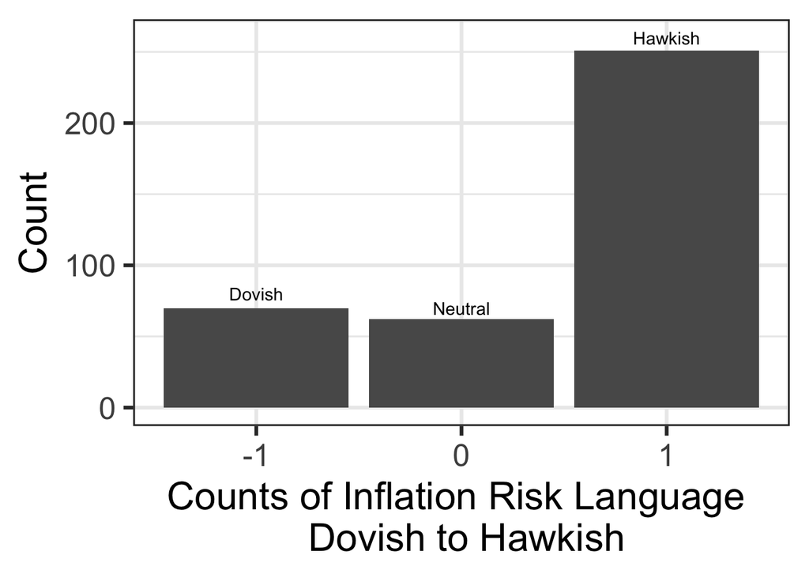

## This replicates table A.1

```r
#dat <- read.csv2("Speaker_meeting_unique.csv", stringsAsFactors = FALSE)
load("Appendix.rda")
str(dat)
```

```
'data.frame':   429 obs. of  4 variables:
 $ X      : int  1 2 3 4 5 6 7 8 9 10 ...
 $ Speaker: chr  "CHAIRMAN GREENSPAN." "MR. BERNANKE." "MR. FERGUSON." "MR. GRAMLICH." ...
 $ file_id: chr  "FOMC20050202meeting.csv" "FOMC20050202meeting.csv" "FOMC20050202meeting.csv" "FOMC20050202meeting.csv" ...
 $ Speech : chr  " Any further questions for our colleagues?  If not, who would like to start the Committee discussion?  Presiden"| __truncated__ " Thank you, Mr. Chairman.  The economic recovery seems well entrenched, and domestic final demand continued str"| __truncated__ " Thank you, Mr. Chairman…
```

```r
inflation <- kwic(dat$Speech, "inflation")
output <- kwic(dat$Speech, "output")
unemployment <- kwic(dat$Speech, "unemployment")
speech <- rbind(inflation, output, unemployment)

#Top Topic Words

top_unigrams <- c("inflation",
"percent",
"year",
"markets",
"financial",
"district",
"president",
"contacts",
"capital",
"terms",
"people",
"laughter",
"monetary",
"output",
"unemployment",
"mortgage",
"ceo",
"december",
"nation",
"statement",
"world",
"katrina",
"largest",
"july",
"florida")

#for (word in top_unigrams) {
#  print(dim(kwic(dat[[4]], word))[1])
#}

count <-NULL

for (word in top_unigrams) {
  result <- dim(kwic(dat[[4]], word))[1]
  count[word] <- result        # change to assignment
}
```

[output not shown]

```r
count
```

```
   inflation      percent         year      markets    financial     district
        2924         1466         1092         1075          603          550
   president     contacts      capital        terms       people     laughter
         532          392          384          370          347          298
    monetary       output unemployment     mortgage          ceo     december
         261          260          245          194          136          128
      nation    statement        world      katrina      largest         july
         126          118          110           96           81           78
     florida
          77
```

```r
counts<- as.data.frame(count)
#xtable(counts)
```

## This replicates table A.2

Recall that our model was:

```r
rf <- ranef(mod.mix, condVar = TRUE)$name
rf_postvar <- as.vector(attr(rf, "postVar"))
df <- data.frame(ideal = rf[[1]]) %>%
  mutate(se = sqrt(rf_postvar),
         upper = ideal + 2 * se,
         lower = ideal - 2 * se,
         speaker = factor(rownames(rf),
                          levels = rownames(rf)[order(ideal)])) %>%
  arrange(ideal)

keep <- c("speaker", "lower", "ideal", "upper")
newdf <- df[keep]
newdf
```

```
     speaker       lower       ideal        upper
1      POOLE -2.58747453 -2.42187985 -2.256285158
2     FISHER -1.35120959 -1.17106680 -0.990924022
3     YELLEN -1.27400332 -1.09960631 -0.925209301
4      EVANS -0.81198085 -0.47637583 -0.140770810
5   GRAMLICH -0.79392994 -0.45360557 -0.113281204
6   PIANALTO -0.64056712 -0.42965676 -0.218746406
7       KOHN -0.59018905 -0.40376550 -0.217341945
8      GUYNN -0.60560728 -0.37645908 -0.147310878
9  GREENSPAN -0.56287687 -0.35219647 -0.141516075
10  FERGUSON -0.47931096 -0.22301298  0.033284988
11    LACKER -0.39886922 -0.20412776 -0.009386303
12      BIES -0.43529632 -0.19934867  0.036598981
13  LOCKHART -0.42662010 -0.10281117  0.220997756
14     STERN -0.32230325 -0.07439540  0.173512454
15   MINEHAN -0.26777758 -0.06644838  0.134880808
16    MOSKOW -0.15439818  0.06609562  0.286589430
17     OLSON -0.12814358  0.23699001  0.602123595
18   PLOSSER  0.05780284  0.28432936  0.510855881
19     WARSH  0.10991766  0.35854955  0.607181438
20  BERNANKE  0.23525681  0.44867338  0.662089948
21     STONE -0.07805681  0.45878064  0.995618086
22 SANTOMERO  0.20532587  0.55689832  0.908470780
23  KROSZNER  0.32001700  0.59800333  0.875989669
24    HOENIG  0.47089411  0.76489352  1.058892917
25  GEITHNER  0.84403499  1.11923504  1.394435096
26   HOLCOMB  0.30354534  1.37902369  2.454502036
27   MISHKIN  1.11423523  1.57783994  2.041444653
```

```r
#tableA2 <- xtable(newdf)
#print(tableA2 , include.rownames = FALSE, digits = c(0,3,3,3)) # row names
```